# Data and analysis quality

Supplement to Figure 1: data and analysis quality. The top row asks whether the samples held up: filtering, detection, intensity before and after normalisation, dynamic range and missingness. The bottom row asks whether the analysis behaves: sample correlation, blood, blood adjustment, p-value calibration and power. The figure reads saved outputs only; the summaries here (ordering, within- and between-subject correlation, histograms) describe them and test nothing.

| panel | shows |
| --- | --- |
| a | proteins left after each filtering step |
| b | share of proteins missing in each of the 48 runs |
| c | each sample’s intensity quantiles before and after cyclic loess |
| d | dynamic range, with abundant muscle proteins named |
| e | share missing against mean observed abundance, with limpa’s detection curve |
| f | correlation between the 45 samples |
| g | blood index per sample, by arm and time |
| h | each protein’s log2 FC with and without the blood covariate |
| i | p-value histograms per contrast |
| j | observed effects in the primary contrast against the effect detectable at 80% power |

## Packages

`figure_theme`, `figure_tags`, the colour sets and `save_figure()` come from the shared helpers in `00_Setup/Shared_functions/`.

```r
suppressPackageStartupMessages({
  library(here)
  library(dplyr)
  library(tidyr)
  library(purrr)
  library(tibble)
  library(ggplot2)
  library(patchwork)
})
source(here("00_Setup", "Shared_functions", "analysis_reporting_helpers.R"))
source(here("00_Setup", "Shared_functions", "figure_style.R"))
source(here("00_Setup", "Shared_functions", "figure_panels.R"))
```

Four workbooks: protein filtering, normalisation, quantification and the HR/LR protein contrasts. The chunk creates `b_reports/` and `c_data/`, stops if any input is missing, and sets the contrast labels and families used by panels h and i.

```r
stage <- here("05_Figures", "Processing", "S01_QC")
figure_dir <- file.path(stage, "b_reports")
out <- file.path(stage, "c_data")
walk(c(figure_dir, out), dir.create, recursive = TRUE, showWarnings = FALSE)

inputs <- c(
  filter = "01_Processing/01_Protein_Filtering/c_data/protein_filtering.xlsx",
  normalize = "01_Processing/02_Normalisation/c_data/normalisation.xlsx",
  quantify = "01_Processing/03_Quantification/c_data/quantification.xlsx",
  contrasts = "03_Group_comparisons/HRvLR/02_Protein_Contrasts/c_data/protein_contrasts.xlsx"
)
paths <- map_chr(inputs, here)
if (!all(file.exists(paths))) {
  stop("Missing inputs: ", paste(inputs[!file.exists(paths)], collapse = ", "))
}
read_sheet <- \(input, sheet) readxl::read_excel(paths[[input]], sheet)
contrast_names <- c(
  Training_HR = "Training HR", Training_LR = "Training LR", Acute_HR = "Acute HR",
  Acute_LR = "Acute LR", Baseline_HRvLR = "HR - LR T1", Trained_HRvLR = "HR - LR T2",
  Acute_HRvLR = "HR - LR T3", Training_Interaction = "Int. training",
  Acute_Interaction = "Int. acute"
)
contrast_family <- c(
  Training_HR = "Training", Training_LR = "Training", Acute_HR = "Acute", Acute_LR = "Acute",
  Baseline_HRvLR = "HR - LR", Trained_HRvLR = "HR - LR", Acute_HRvLR = "HR - LR",
  Training_Interaction = "Interaction", Acute_Interaction = "Interaction"
)
time_axis <- scale_colour_manual(values = time_colours, name = NULL)
```

## a: filtering

Proteins left after each filtering step, from the filtering log.

```r
filter_log <- read_sheet("filter", "filter_log") |>
  mutate(step = factor(step, rev(step)))
panel_filter <- ggplot(filter_log, aes(n_after, step)) +
  geom_col(fill = "grey70", width = 0.7) +
  geom_text(aes(label = n_after), hjust = 1.1, size = 1.8, colour = "white") +
  labs(
    x = "proteins remaining", y = NULL, title = "Filtering",
    subtitle = sprintf("%d to %d proteins", max(filter_log$n_after), min(filter_log$n_after))
  ) +
  figure_theme +
  theme(panel.grid.major.y = element_blank())
```

## b: detection per run

Share of proteins missing in each of the 48 runs. The three runs not carried forward are the ones absent from the 45-sample blood table that `03_Quantification` writes.

```r
kept_samples <- read_sheet("quantify", "blood")$sample_id
detection <- read_sheet("filter", "outlier_diagnostics") |>
  mutate(
    kept = sample_id %in% kept_samples,
    sample_id = factor(sample_id, sample_id[order(arm, timepoint, pct_missing)])
  )
panel_detection <- ggplot(detection, aes(sample_id, pct_missing, colour = timepoint)) +
  geom_segment(aes(xend = sample_id, y = 0, yend = pct_missing), linewidth = 0.3) +
  geom_point(aes(shape = kept), size = 1.2) +
  facet_grid(~arm, scales = "free_x", space = "free_x") +
  scale_shape_manual(
    values = c(`TRUE` = 16, `FALSE` = 4), labels = c("excluded", "kept"), name = NULL
  ) +
  time_axis +
  labs(
    x = "run", y = "% of proteins missing", title = "Detection per run",
    subtitle = sprintf("%d runs; %d excluded as outliers", nrow(detection), sum(!detection$kept))
  ) +
  figure_theme +
  theme(axis.text.x = element_blank(), panel.grid.major.x = element_blank())
```

## c: intensity per sample

Each sample’s intensity quantiles (5, 25, 50, 75 and 95%) before and after cyclic loess, from the normalisation workbook.

```r
quantiles <- read_sheet("normalize", "intensity_quantiles") |>
  mutate(
    stage = factor(stage, c("before", "after"), c("before normalisation", "after")),
    sample_id = factor(sample_id, unique(sample_id[order(arm, timepoint)]))
  )
panel_intensity <- ggplot(quantiles, aes(sample_id, colour = timepoint)) +
  geom_linerange(aes(ymin = q05, ymax = q95), linewidth = 0.25) +
  geom_linerange(aes(ymin = q25, ymax = q75), linewidth = 0.9) +
  geom_point(aes(y = q50), colour = "white", size = 0.4) +
  facet_wrap(~stage, ncol = 1) +
  time_axis +
  labs(
    x = "sample", y = "log2 intensity", title = "Intensity per sample",
    subtitle = "median, 25-75% and 5-95% of proteins"
  ) +
  figure_theme +
  theme(axis.text.x = element_blank(), panel.grid.major.x = element_blank())
```

## d: dynamic range

Proteins ranked by mean log2 abundance over the complete matrix, with ten abundant muscle proteins named.

```r
protein_table <- read_sheet("quantify", "proteins") |>
  arrange(desc(mean_complete)) |>
  mutate(rank = row_number())
landmarks <- c("MYH7", "MYH2", "ACTA1", "TTN", "DES", "CKM", "MB", "ATP5F1A", "NDUFA4", "PSMA1")
named <- filter(protein_table, gene %in% landmarks)
panel_range <- ggplot(protein_table, aes(rank, mean_complete)) +
  geom_point(size = 0.3, colour = "grey60") +
  geom_point(data = named, size = 1, colour = "black") +
  ggrepel::geom_text_repel(
    aes(label = gene), named,
    size = 1.8, min.segment.length = 0, segment.size = 0.2, seed = 1
  ) +
  labs(
    x = "rank by mean abundance", y = "mean log2 abundance", title = "Dynamic range",
    subtitle = sprintf(
      "%d proteins over %.1f log2 units",
      nrow(protein_table), diff(range(protein_table$mean_complete))
    )
  ) +
  figure_theme
```

## e: missing because faint

Share missing against mean observed abundance. The line is limpa’s detection probability curve: a logistic fit of the chance a value is observed against its abundance, drawn from the intercept and slope that `03_Quantification` saved.

```r
curve <- read_sheet("quantify", "curve")
dpc <- tibble(mean_observed = seq(
  min(protein_table$mean_observed), max(protein_table$mean_observed),
  length.out = 200
)) |>
  mutate(missing = 1 - plogis(curve$estimate[1] + curve$estimate[2] * mean_observed))
panel_missing <- ggplot(protein_table, aes(mean_observed, 1 - prop_observed)) +
  geom_point(size = 0.3, alpha = 0.4, colour = "grey40") +
  geom_line(aes(y = missing), dpc, colour = contrast_tone("line")[["HR - LR"]], linewidth = 0.6) +
  scale_y_continuous(labels = scales::label_percent()) +
  labs(
    x = "mean log2 abundance where observed", y = "values missing",
    title = "Missing because faint",
    subtitle = sprintf(
      "%.1f%% missing; line: limpa detection curve, slope %.2f",
      curve$pct_missing[1], curve$estimate[2]
    )
  ) +
  figure_theme
```

## f: sample correlation

Correlation between the 45 samples, each protein centred, ordered by average-linkage clustering on 1 - r. The chunk also takes the median r for pairs from the same person and from different people. The diagonal (r = 1) is left blank so it does not set the colour range.

```r
correlation <- read_sheet("quantify", "sample_correlation")
r <- as.matrix(column_to_rownames(correlation, "sample_id"))
ordering <- rownames(r)[hclust(as.dist(1 - r), method = "average")$order]
subject_of <- set_names(read_sheet("quantify", "blood")$subject, kept_samples)
pairs <- as_tibble(r, rownames = "a") |>
  pivot_longer(-a, names_to = "b", values_to = "r") |>
  filter(a < b) |>
  mutate(same = subject_of[a] == subject_of[b])
within_between <- summarise(pairs, r = median(r), .by = same)
cells <- as_tibble(r, rownames = "a") |>
  pivot_longer(-a, names_to = "b", values_to = "r") |>
  mutate(r = if_else(a == b, NA_real_, r), a = factor(a, ordering), b = factor(b, ordering))
panel_correlation <- ggplot(cells, aes(a, b, fill = r)) +
  geom_tile() +
  scale_fill_distiller(
    palette = "RdBu", limits = c(-0.6, 0.6), breaks = c(-0.5, 0, 0.5), name = "r",
    oob = scales::squish, na.value = "white"
  ) +
  labs(
    x = NULL, y = NULL, title = "Sample correlation",
    subtitle = sprintf(
      "median r: same person %.2f, different people %.2f",
      within_between$r[within_between$same], within_between$r[!within_between$same]
    )
  ) +
  figure_theme +
  theme(axis.text = element_blank(), panel.grid = element_blank())
```

## g: blood

Blood index per sample, by arm and time. The subtitle carries the LR - HR difference at T3 and its permutation p from `01_Protein_Filtering`.

```r
blood <- read_sheet("quantify", "blood") |>
  mutate(arm = sub("_.*", "", group), timepoint = sub(".*_", "", group))
blood_test <- filter(read_sheet("filter", "blood_by_arm"), scale == "log2_index")
panel_blood <- ggplot(blood, aes(timepoint, blood_rel, colour = timepoint, shape = arm)) +
  geom_point(position = position_jitterdodge(jitter.width = 0.15, seed = 1), size = 1.1) +
  scale_shape_manual(values = arm_shapes, name = NULL) +
  time_axis +
  labs(
    x = NULL, y = "blood index (log2, vs sample median)", title = "Blood in each biopsy",
    subtitle = sprintf(
      "LR - HR at T3 %.2f, permutation p = %.2g", blood_test$lr_minus_hr_at_t3,
      blood_test$permutation_p
    )
  ) +
  figure_theme
```

## h: blood adjustment

Each protein’s log2 FC with and without the blood covariate, every contrast pooled. `dep` holds one row per protein with logFC and p per contrast, as the unadjusted sheet is laid out.

```r
dep <- read_sheet("contrasts", "protein_by_contrast") |>
  pivot_wider(
    id_cols = uniprot_id, names_from = contrast, values_from = c(logFC, p),
    names_glue = "{contrast}_{.value}"
  )
unadjusted <- read_sheet("contrasts", "unadjusted")
blood_effect <- names(contrast_family) |>
  map(\(cn) {
    tibble(
      contrast = cn, family = contrast_family[[cn]],
      adjusted = dep[[paste0(cn, "_logFC")]],
      unadjusted = unadjusted[[paste0(cn, "_logFC")]][match(dep$uniprot_id, unadjusted$uniprot_id)]
    )
  }) |>
  list_rbind()
blood_r <- cor(blood_effect$adjusted, blood_effect$unadjusted)
panel_blood_fit <- ggplot(blood_effect, aes(unadjusted, adjusted, colour = family)) +
  geom_abline(linetype = "dashed", linewidth = 0.25) +
  geom_point(size = 0.2, alpha = 0.3) +
  scale_colour_manual(values = contrast_tone("line"), name = NULL) +
  guides(colour = guide_legend(override.aes = list(size = 1.5, alpha = 1))) +
  labs(
    x = "log2 FC without blood covariate", y = "log2 FC with blood covariate",
    title = "Blood adjustment", subtitle = sprintf("nine contrasts pooled, r = %.3f", blood_r)
  ) +
  figure_theme
```

## i: p-value calibration

p-value histograms per contrast. The dashed line is a flat null: the count each 0.05-wide bin holds if no protein changes. Each facet also gives the contrast’s median |t|, which is 0.67 under the null.

```r
calibration <- read_sheet("contrasts", "null_calibration")
p_values <- names(contrast_family) |>
  map(\(cn) tibble(contrast = cn, family = contrast_family[[cn]], p = dep[[paste0(cn, "_p")]])) |>
  list_rbind() |>
  mutate(contrast = factor(contrast, names(contrast_family)))
panel_p <- ggplot(p_values, aes(p, fill = family)) +
  geom_histogram(binwidth = 0.05, boundary = 0) +
  geom_hline(yintercept = nrow(dep) / 20, linetype = "dashed", linewidth = 0.25) +
  geom_text(
    aes(0.5, Inf, label = sprintf("median |t| %.2f", median_abs_t)),
    mutate(calibration, contrast = factor(contrast, names(contrast_family))),
    inherit.aes = FALSE, vjust = 1.3, size = 1.6
  ) +
  facet_wrap(~contrast, ncol = 3, labeller = as_labeller(contrast_names)) +
  scale_fill_manual(values = contrast_tone("fill"), guide = "none") +
  scale_x_continuous(breaks = c(0, 0.5, 1), labels = c("0", "0.5", "1")) +
  labs(
    x = "p", y = "proteins", title = "p-value calibration",
    subtitle = "dashed: flat null; median |t| is 0.67 under the null"
  ) +
  figure_theme +
  theme(
    strip.text = element_text(size = 5), panel.grid.minor = element_blank(),
    panel.spacing.x = unit(2.5, "mm")
  )
```

## j: power

Observed |log2 FC| in the primary contrast, the training interaction, against the effect it can detect at 80% power for the median protein and the 90th percentile protein.

```r
detectable <- read_sheet("contrasts", "detectable_effect")
observed <- tibble(effect = abs(dep$Training_Interaction_logFC))
panel_power <- ggplot(observed, aes(effect)) +
  geom_histogram(binwidth = 0.1, boundary = 0, fill = contrast_tone("fill")[["Interaction"]]) +
  geom_vline(
    aes(xintercept = log2_fc, linetype = factor(quantile)), detectable,
    linewidth = 0.4, colour = contrast_tone("line")[["Interaction"]]
  ) +
  scale_linetype_manual(
    values = c(`0.5` = "solid", `0.9` = "dashed"),
    labels = c("median protein", "90th percentile"), name = "detectable at 80% power"
  ) +
  labs(
    x = "|log2 FC|, training interaction", y = "proteins", title = "Power",
    subtitle = sprintf(
      "%.0f%% of effects below the median detectable %.2f",
      100 * mean(observed$effect < detectable$log2_fc[detectable$quantile == 0.5]),
      detectable$log2_fc[detectable$quantile == 0.5]
    )
  ) +
  figure_theme +
  theme(legend.position = "bottom", legend.title.position = "top")
```

## Validation

Every plotted number traces to its source table before anything is written. The chunk stops if the filtered protein count, the run and sample counts, the correlation matrix shape, the blood matching, or the calibration and power tables differ from what the panels assume.

```r
stopifnot(
  min(filter_log$n_after) == nrow(protein_table),
  nrow(detection) == 48, sum(!detection$kept) == 3, length(kept_samples) == 45,
  nrow(quantiles) == 2 * 45, nrow(r) == 45, isSymmetric(r),
  all(!is.na(blood_effect$unadjusted)), nrow(p_values) == 9 * nrow(dep),
  nrow(calibration) == 9, nrow(detectable) == 2
)
```

## Figure

The chunk assembles the ten panels in two rows, writes `b_reports/s01_qc.pdf` at 300 by 190 mm, and prints the figure.

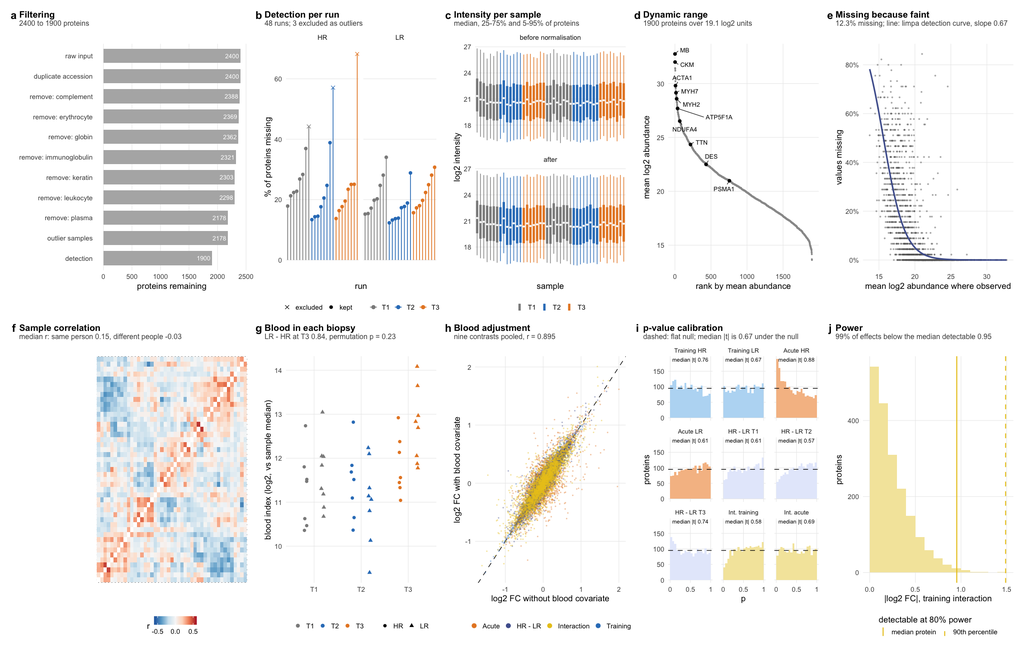

Figure 1: Data and analysis quality.

```r
figure <- wrap_plots(
  panel_filter, panel_detection, panel_intensity, panel_range, panel_missing,
  panel_correlation, panel_blood, panel_blood_fit, panel_p, panel_power,
  nrow = 2
) +
  plot_annotation(tag_levels = "a") &
  figure_tags &
  theme(legend.position = "bottom", legend.key.size = unit(2.5, "mm"))
save_figure(figure, figure_dir, "s01_qc", width = 300, height = 190)
print(figure)
```

## Save

`c_data/s01_qc.xlsx` holds the numbers behind each panel, one sheet per panel, with the input manifest.

```r
sheets <- list(
  filter_log = select(filter_log, step, n_removed, n_after),
  detection = select(detection, sample_id, subject, arm, timepoint, pct_missing, kept),
  intensity_quantiles = select(quantiles, -arm, -timepoint),
  dynamic_range = select(protein_table, uniprot_id, gene, rank, mean_complete),
  missingness = select(protein_table, uniprot_id, gene, mean_observed, prop_observed),
  correlation_summary = within_between,
  blood = select(blood, sample_id, subject, arm, timepoint, blood_rel),
  blood_adjustment = tibble(r = blood_r, n_points = nrow(blood_effect)),
  calibration = calibration,
  power = detectable
)
holds <- c(
  "Panel a: proteins removed and remaining at each filtering step.",
  "Panel b: share of proteins missing per run, and whether the run was kept.",
  "Panel c: per-sample log2 intensity quantiles before and after cyclic loess.",
  "Panel d: proteins ranked by mean log2 abundance over the complete matrix.",
  "Panel e: per protein, mean observed abundance and share of values observed.",
  "Panel f: median sample correlation within and between people.",
  "Panel g: blood index per sample.",
  "Panel h: correlation of log2 FC with and without the blood covariate, nine contrasts pooled.",
  "Panel i: per contrast, propTrueNull, median |t| and share of p below 0.2.",
  "Panel j: log2 FC the training interaction detects at 80% power."
)
write_workbook(sheets, holds, file.path(out, "s01_qc.xlsx"), inputs, paths)
```